# Programming - Dates/Times and Functions-part 1

# Ch. 16 Dates and Times

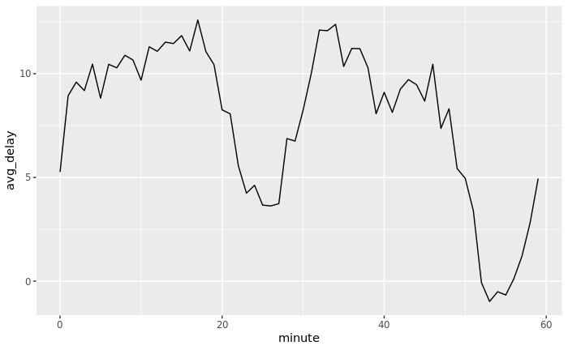

An alternative approach to plotting individual components is to round the date to a nearby unit of time, with floor_date(), round_date(), and ceiling_date()

```r
datetime #> [1] "2020-01-08 12:34:56 UTC"
```

```
[1] "2020-01-08 12:34:56 UTC"
```

If values are too big, they will roll-over

How does the distribution of flight times within a day change over the course of the year? There is not much of a change.

Compare dep_time, sched_dep_time and dep_delay. Are they consistent? Explain your findings.

| dep_time_ | dep_time | sched_dep_time | dep_delay |
| --- | --- | --- | --- |
| 2013-01-02 08:48:00 | 2013-01-01 08:48:00 | 2013-01-01 18:35:00 | 853 |
| 2013-01-03 00:42:00 | 2013-01-02 00:42:00 | 2013-01-02 23:59:00 | 43 |
| 2013-01-03 01:26:00 | 2013-01-02 01:26:00 | 2013-01-02 22:50:00 | 156 |
| 2013-01-04 00:32:00 | 2013-01-03 00:32:00 | 2013-01-03 23:59:00 | 33 |
| 2013-01-04 00:50:00 | 2013-01-03 00:50:00 | 2013-01-03 21:45:00 | 185 |
| 2013-01-04 02:35:00 | 2013-01-03 02:35:00 | 2013-01-03 23:59:00 | 156 |
| 2013-01-05 00:25:00 | 2013-01-04 00:25:00 | 2013-01-04 23:59:00 | 26 |
| 2013-01-05 01:06:00 | 2013-01-04 01:06:00 | 2013-01-04 22:45:00 | 141 |
| 2013-01-06 00:14:00 | 2013-01-05 00:14:00 | 2013-01-05 23:59:00 | 15 |
| 2013-01-06 00:37:00 | 2013-01-05 00:37:00 | 2013-01-05 22:30:00 | 127 |

[output cut: 990 more lines]

There are discrepancies. It looks like there are mistakes in the dates. The code would have had to check if the departure time is less than the scheduled departure time plus departure delay (in minutes). If they were consistent, then `dep_time = sched_dep_time + dep_delay`

Compare air_time with the duration between the departure and arrival. Explain your findings. (Hint: consider the location of the airport.)

| origin | dest | flight_duration | air_time_mins | diff |
| --- | --- | --- | --- | --- |
| EWR | IAH | 193 | 227 | -34 |
| LGA | IAH | 197 | 227 | -30 |
| JFK | MIA | 221 | 160 | 61 |
| JFK | BQN | 260 | 183 | 77 |
| LGA | ATL | 138 | 116 | 22 |
| EWR | ORD | 106 | 150 | -44 |
| EWR | FLL | 198 | 158 | 40 |
| LGA | IAD | 72 | 53 | 19 |
| JFK | MCO | 161 | 140 | 21 |
| LGA | ORD | 115 | 138 | -23 |

[output cut: 990 more lines]

How does the average delay time change over the course of a day? Should you use dep_time or sched_dep_time? Why? Use `sched_dep_time` because that is the relevant metric for someone scheduling a flight. Also, using `dep_time` will always bias delays to later in the day since delays will push flights later.

On what day of the week should you leave if you want to minimise the chance of a delay? Saturday

What makes the distribution of diamonds$carat and flights$sched_dep_time similar?

```r
flights$sched_dep_time
```

[output not shown]

[output cut: 32 more lines]

Confirm my hypothesis that the early departures of flights in minutes 20-30 and 50-60 are caused by scheduled flights that leave early. Hint: create a binary variable that tells you whether or not a flight was delayed.

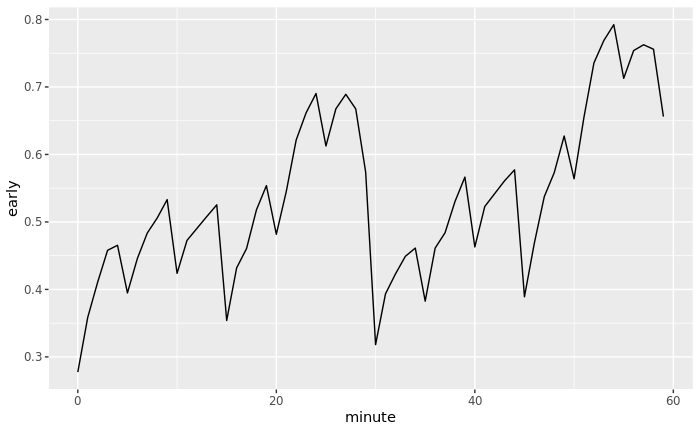

```r
years(1) / days(1) #365
```

```
estimate only: convert to intervals for accuracy
```

```
[1] 365.25
```

Why is there months() but no dmonths()? There is no direct unambiguous value of months in seconds

Explain days(overnight * 1) to someone who has just started learning R. How does it work? The variable `overnight` is equal to `TRUE` or `FALSE`. If it is an overnight flight, this becomes 1 day, and if not, then overnight = 0, and no days are added to the date.

```r
floor_date(today(), unit = "year") + months(0:11)
```

```
 [1] "2019-01-01" "2019-02-01" "2019-03-01" "2019-04-01" "2019-05-01" "2019-06-01" "2019-07-01" "2019-08-01"
 [9] "2019-09-01" "2019-10-01" "2019-11-01" "2019-12-01"
```

Write a function that given your birthday (as a date), returns how old you are in years.

```r
age(ymd("1999-06-13"))
```

```
[1] 20
```

Why can’t (today() %–% (today() + years(1)) / months(1) work? The numerator of the expression is an interval with includes both a duration of time and a starting point. The denominator of the expression, `months(1)`, is a period, which is meaningful to humans but not defined in terms of an exact number of seconds.

```r
Sys.timezone()
```

```
[1] "America/Los_Angeles"
```